# ENCE - Sequential vs Synchonous Updates

Investigating the convergence behaviour of the Elastic-net Chained Equations (ENCE) algorithm with Sequential vs Synchonous updates.

The original ENCE algorithm imputes each column of the data matrix $Z$ column-by-column within an outer cycle, where each station’s regression model is fit using the most recently imputed values of all other stations.

The alternative algorithm considered here updates all stations within a cycle against a frozen snapshot of $Z$ taken at the start of that cycle, so the update order within a cycle no longer matters. The motivation for this change is to allow for parallelism.

Further details of ENCE can be found in the study at https://doi.org/10.1002/joc.8513 The data that support the findings of this study are available upon reasonable request to the author(s) and with the permission of Met Éireann, Ireland’s meteorological office.

## Setup

Load the simulated data and source both ENCE variants.

```r
source("idw.R")
source("ENCE_serial.R")     # sequential updates
source("ENCE_parallel.R")   # synchronous updates (serial execution for now)

#n_stations <- 50
#n_months   <- 60

rain <- read.csv("simulated_rainfall.csv")
#rain <- rain[rain$stno <= n_stations & rain$t <= n_months, ] # Simulating a smaller subset of data for now
```

## Imputation

Mask 25% of the data uniformly at random and run both variants from the same starting point. The plots that follow compare convergence behaviour and imputation accuracy.

```r
df_miss <- rain
set.seed(313)
sample_rows <- sort(sample(nrow(df_miss), nrow(df_miss) * 0.25))
df_miss[sample_rows, "y"] <- NA
```

Run both variants on the masked data:

```r
source("ENCE_serial.R")
imp_seq <- ENCE(df_miss, response = "y", max_cycles = 30,
               init_method = "idw",
               x_name = "east", y_name = "north", t_name = "t",
               C = 15000,
               transformation = sqrt,
               reverse_transformation = function(x) x^2,
               truth = rain$y, masked_idx = sample_rows)
rmse_seq     <- attr(imp_seq, "rmse_history")
ext_rmse_seq <- attr(imp_seq, "ext_rmse_history")

source("ENCE_parallel.R")
imp_sync <- ENCE(df_miss, response = "y", max_cycles = 30,
               init_method = "idw",
               x_name = "east", y_name = "north", t_name = "t",
               C = 15000,
               transformation = sqrt,
               reverse_transformation = function(x) x^2,
               truth = rain$y, masked_idx = sample_rows)
rmse_sync     <- attr(imp_sync, "rmse_history")
ext_rmse_sync <- attr(imp_sync, "ext_rmse_history")
```

Plot 1: Internal Convergence

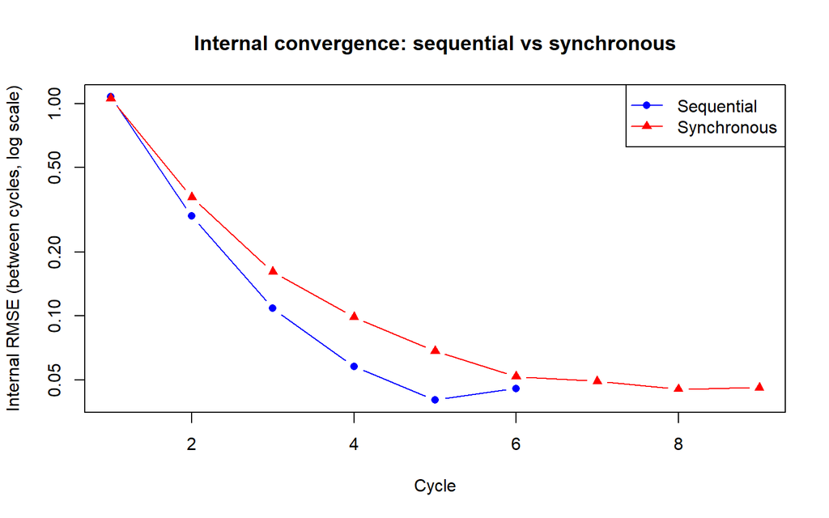

```r
xlim_range <- c(1, max(length(rmse_seq), length(rmse_sync)))

plot(rmse_seq, type = "b", col = "blue", pch = 16, log = "y",
     xlim = xlim_range,
     ylim = range(c(rmse_seq, rmse_sync)),
     xlab = "Cycle", ylab = "Internal RMSE (between cycles, log scale)",
     main = "Internal convergence: sequential vs synchronous")
lines(rmse_sync, type = "b", col = "red", pch = 17)
legend("topright", legend = c("Sequential", "Synchronous"),
       col = c("blue", "red"), pch = c(16, 17), lty = 1)
```

Plot 2: Validation RMSE

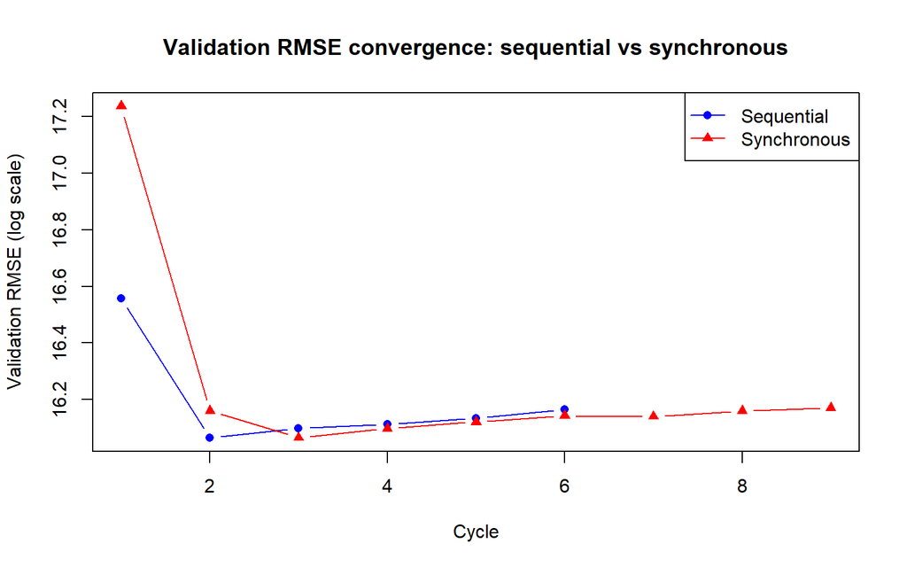

```r
xlim_range <- c(1, max(length(ext_rmse_seq), length(ext_rmse_sync)))

plot(ext_rmse_seq, type = "b", col = "blue", pch = 16,
     xlim = xlim_range,
     ylim = range(c(ext_rmse_seq, ext_rmse_sync)),
     xlab = "Cycle", ylab = "Validation RMSE (log scale)",
     main = "Validation RMSE convergence: sequential vs synchronous")
lines(ext_rmse_sync, type = "b", col = "red", pch = 17)
legend("topright", legend = c("Sequential", "Synchronous"),
       col = c("blue", "red"), pch = c(16, 17), lty = 1)
```

Plot 3: Imputed vs true at convergence

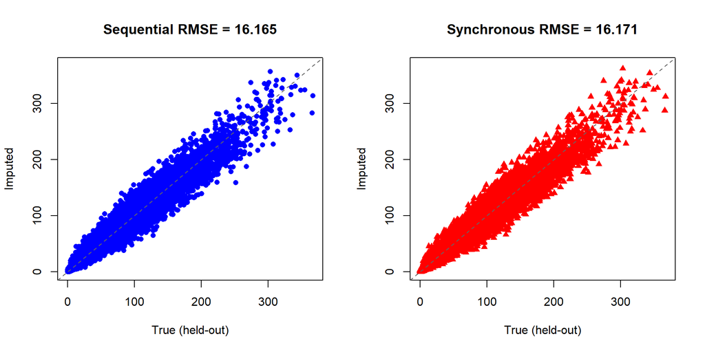

```r
truth     <- rain$y[sample_rows]
pred_seq  <- imp_seq$y[sample_rows]
pred_sync <- imp_sync$y[sample_rows]

rmse_ext_seq  <- sqrt(mean((truth - pred_seq)^2))
rmse_ext_sync <- sqrt(mean((truth - pred_sync)^2))

lim <- range(c(truth, pred_seq, pred_sync))

par(mfrow = c(1, 2))

plot(truth, pred_seq, pch = 16, col = "blue",
     xlim = lim, ylim = lim,
     xlab = "True (held-out)", ylab = "Imputed",
     main = sprintf("Sequential RMSE = %.3f", rmse_ext_seq))
abline(0, 1, lty = 2, col = "grey40")

plot(truth, pred_sync, pch = 17, col = "red",
     xlim = lim, ylim = lim,
     xlab = "True (held-out)", ylab = "Imputed",
     main = sprintf("Synchronous RMSE = %.3f", rmse_ext_sync))
abline(0, 1, lty = 2, col = "grey40")
```

```r
par(mfrow = c(1, 1))
```